# Summer2025-HW1-SOLUTION-R

--- title: "Spring2025-HW1" output: html_document date: "2025-01-26" ---

```r
knitr::opts_chunk$set(echo = TRUE)
```

## **Sales and Customer Interaction Dataset**

In this homework, you have been given a dataset that captures comprehensive details of 1,000 sales transactions made in 2024, focusing on various aspects of customer interactions and sales dynamics. It includes a mix of numeric and categorical variables, allowing for in-depth analysis.

Key features of the dataset include:

- **Customer_ID**: Unique identifier for each customer.
- **Product_Category**: Category of the purchased product (e.g., Electronics, Clothing, Home Appliances, etc.).
- **Purchase_Amount**: Total amount spent on each purchase, in dollars.
- **Purchase_Date**: Date of the transaction
- **Customer_Age**: Age of the customer at the time of purchase.
- **Customer_Gender**: Gender of the customer, Male or Female
- **Store_Location**: Location of the store where the purchase occurred.
- **Satisfaction_Score (response variable)** : Numeric response variable indicating the customer's satisfaction level

  **Note:**

  For the first homework assignment, we have provided the pre-processing steps for the variables. Kindly ensure you understand and can modify these steps as needed. In future homework and exams, students will be expected to handle data pre-processing independently, and no code will be provided. The only aspect that should remain unchanged is the seed setting to 100.

```r
set.seed(100) #this seed has been set to 100 to ensure results are reproducible. DO NOT CHANGE THIS SEED

Sales_dataset = read.csv("large_sales_dataset.csv", header=TRUE) #reads data
Sales_dataset$Product_Category=as.factor(Sales_dataset$Product_Category)
Sales_dataset$Purchase_Date=as.Date(Sales_dataset$Purchase_Date, format="%m/%d/%Y")
Sales_dataset$Customer_Gender=as.factor(Sales_dataset$Customer_Gender)
Sales_dataset$Store_Location=as.factor(Sales_dataset$Store_Location)

head(Sales_dataset)

#Dividing the dataset into training and testing datasets
testRows_sales = sample(nrow(Sales_dataset),0.2*nrow(Sales_dataset))
testData_sales = Sales_dataset[testRows_sales, ]
trainData_sales = Sales_dataset[-testRows_sales, ]
row.names(trainData_sales) <- NULL
head(trainData_sales)
```

| Customer_ID | Product_Category | Purchase_Amount | Purchase_Date | Customer_Age | Customer_Gender | Store_Location | Satisfaction_Score |
| --- | --- | --- | --- | --- | --- | --- | --- |
| 101 | Books | 1091.97 | 2024-07-24 | 62 | Female | Chicago | 7.281961 |
| 102 | Furniture | 869.33 | 2024-05-04 | 62 | Female | New York | 8.124978 |
| 102 | Books | 1592.04 | 2024-12-29 | 62 | Female | Boston | 8.229209 |
| 102 | Electronics | 1600.56 | 2024-12-07 | 62 | Female | Boston | 8.882945 |
| 105 | Toys | 1030.42 | 2024-02-20 | 35 | Female | Atlanta | 6.811557 |
| 105 | Books | 383.44 | 2024-11-25 | 35 | Female | San Diego | 5.779122 |

| Customer_ID | Product_Category | Purchase_Amount | Purchase_Date | Customer_Age | Customer_Gender | Store_Location | Satisfaction_Score |
| --- | --- | --- | --- | --- | --- | --- | --- |
| 102 | Furniture | 869.33 | 2024-05-04 | 62 | Female | New York | 8.124978 |
| 102 | Books | 1592.04 | 2024-12-29 | 62 | Female | Boston | 8.229209 |
| 102 | Electronics | 1600.56 | 2024-12-07 | 62 | Female | Boston | 8.882945 |
| 105 | Toys | 1030.42 | 2024-02-20 | 35 | Female | Atlanta | 6.811557 |
| 105 | Books | 383.44 | 2024-11-25 | 35 | Female | San Diego | 5.779122 |
| 109 | Electronics | 1632.42 | 2024-04-12 | 27 | Male | Boston | 10.000000 |

## Question 1: Data Analysis (8 points)

**For this question, use the "Sales_dataset"**

**1a)(4 points) Output a table that has both the average and median Purchase_Amount grouped by Product_Category, Customer_Gender and Customer_Age. Show the last 15 rows of the table**

**Note: For age group, use the following bins**

**'0-18', '19-25', '26-35', '36-45', '46-55', '56-65', '66-75', '76-85', '86-100'**

```r
library(dplyr)
```

```r
# Define age groups
Sales_dataset <- Sales_dataset %>%
          mutate(Age_Group = cut(Customer_Age,
                         breaks = c(0, 18, 25, 35, 45, 55, 65, 75, 85, 100),
                         labels = c('0-18', '19-25', '26-35', '36-45',
                                    '46-55', '56-65', '66-75', '76-85', '86-100')))

# Calculate the average purchase amount for each product category by customer gender and age group
avg_purchase_amount <- Sales_dataset %>%
  group_by(Product_Category, Customer_Gender, Age_Group) %>%
  summarise(Average_Purchase_Amount = mean(Purchase_Amount, na.rm = TRUE),
            median_Purchase_Amount = median(Purchase_Amount, na.rm = TRUE)
  )
```

```r
avg_purchase_amount=data.frame(avg_purchase_amount)
# Print the result
print(tail(avg_purchase_amount,15))
```

```
   Product_Category Customer_Gender Age_Group Average_Purchase_Amount
67  Home Appliances            Male     46-55               1372.4186
68  Home Appliances            Male     56-65               1109.0250
69  Home Appliances            Male     66-75                895.0467
70             Toys          Female     19-25               1013.3938
71             Toys          Female     26-35               1026.6828
72             Toys          Female     36-45                586.4117
73             Toys          Female     46-55               1053.0707
74             Toys          Female     56-65                948.3589
75             Toys          Female     66-75                929.2667
76             Toys            Male      0-18               1114.6050
77             Toys            Male     19-25               1139.0450
78             Toys            Male     26-35               1155.0389
79             Toys            Male     36-45                931.8800
80             Toys            Male     46-55                778.1600
```

[output cut: 17 more lines]

**Q1b)(2 points) Which customer age group has the highest total purchase amount across all categories?**

```r
# Calculate the total purchase amount for each age group
total_purchase_by_age_group <- Sales_dataset %>%
  group_by(Age_Group) %>%
  summarise(Total_Purchase_Amount = sum(Purchase_Amount, na.rm = TRUE))

# Identify the age group with the highest total purchase amount
highest_total_purchase_age_group <- total_purchase_by_age_group %>%
  filter(Total_Purchase_Amount == max(Total_Purchase_Amount))

# Print the result
print(highest_total_purchase_age_group)
```

```
# A tibble: 1 x 2
  Age_Group Total_Purchase_Amount
  <fct>                     <dbl>
1 26-35                   279965.
```

**Q1c)(2 points) Which product category has the highest average satisfaction score, and in which location is it most frequently purchased?**

```r
# Calculate the average satisfaction score for each product category
average_satisfaction_score <- Sales_dataset %>%
  group_by(Product_Category) %>%
  summarise(Average_Satisfaction_Score = mean(Satisfaction_Score, na.rm = TRUE))

# Identify the product category with the highest average satisfaction score
highest_satisfaction_category <- average_satisfaction_score %>%
  filter(Average_Satisfaction_Score == max(Average_Satisfaction_Score))

# Get the name of the product category with the highest satisfaction score
highest_category <- highest_satisfaction_category$Product_Category

# Determine the most frequent store location for the identified product category
most_frequent_location <- Sales_dataset %>%
  filter(Product_Category == highest_category) %>%
  count(Store_Location) %>%
  filter(n == max(n))

# Print the results
print(highest_satisfaction_category)
```

```
# A tibble: 1 x 2
  Product_Category Average_Satisfaction_Score
  <fct>                                 <dbl>
1 Electronics                            8.88
```

```r
print(most_frequent_location)
```

```
# A tibble: 1 x 2
  Store_Location     n
  <fct>          <int>
1 Boston            23
```

## Question 2: Time Series Analysis (8 points)

**For this question, use "Sales_dataset"**

**Q2a) (3 points) Calculate the monthly average sales per product category and plot them.**

```r
library(ggplot2)
library(lubridate)
```

```r
Sales_dataset <- Sales_dataset %>%
  mutate(Month = floor_date(Purchase_Date, unit = "month"))

monthly_avg_sales_per_category <- Sales_dataset %>%
  group_by(Month, Product_Category) %>%
  summarise(Average_Sales = mean(Purchase_Amount, na.rm = TRUE)) %>%
  ungroup()
```

```r
monthly_avg_sales_per_category
```

| Month | Product_Category | Average_Sales |
| --- | --- | --- |
| 2024-01-01 | Books | 997.3082 |
| 2024-01-01 | Clothing | 895.7071 |
| 2024-01-01 | Electronics | 938.7827 |
| 2024-01-01 | Furniture | 813.5247 |
| 2024-01-01 | Home Appliances | 930.0371 |
| 2024-01-01 | Toys | 649.0270 |
| 2024-02-01 | Books | 1001.6269 |
| 2024-02-01 | Clothing | 1065.4533 |
| 2024-02-01 | Electronics | 1081.9100 |
| 2024-02-01 | Furniture | 836.5244 |
| 2024-02-01 | Home Appliances | 1148.9210 |
| 2024-02-01 | Toys | 1155.2109 |
| 2024-03-01 | Books | 1066.6637 |
| 2024-03-01 | Clothing | 648.8207 |
| 2024-03-01 | Electronics | 1285.9767 |
| 2024-03-01 | Furniture | 998.2787 |
| 2024-03-01 | Home Appliances | 1063.3775 |
| 2024-03-01 | Toys | 903.8385 |
| 2024-04-01 | Books | 934.1618 |
| 2024-04-01 | Clothing | 896.3175 |
| 2024-04-01 | Electronics | 1057.2980 |
| 2024-04-01 | Furniture | 1095.9525 |
| 2024-04-01 | Home Appliances | 669.7700 |
| 2024-04-01 | Toys | 1022.5579 |
| 2024-05-01 | Books | 1252.2979 |
| 2024-05-01 | Clothing | 1045.9373 |
| 2024-05-01 | Electronics | 1148.4375 |
| 2024-05-01 | Furniture | 945.9878 |
| 2024-05-01 | Home Appliances | 1143.1437 |
| 2024-05-01 | Toys | 1006.3000 |
| ... | ... | ... |
| 2024-08-01 | Books | 1315.5630 |
| 2024-08-01 | Clothing | 1126.9488 |
| 2024-08-01 | Electronics | 657.5047 |
| 2024-08-01 | Furniture | 1002.5210 |
| 2024-08-01 | Home Appliances | 1161.7427 |
| 2024-08-01 | Toys | 1172.7019 |
| 2024-09-01 | Books | 1054.5607 |
| 2024-09-01 | Clothing | 1086.1820 |
| 2024-09-01 | Electronics | 766.7374 |
| 2024-09-01 | Furniture | 977.7800 |
| 2024-09-01 | Home Appliances | 917.9950 |
| 2024-09-01 | Toys | 1020.0579 |
| 2024-10-01 | Books | 1252.7620 |
| 2024-10-01 | Clothing | 962.7450 |
| 2024-10-01 | Electronics | 833.2672 |
| 2024-10-01 | Furniture | 501.0362 |
| 2024-10-01 | Home Appliances | 1010.8495 |
| 2024-10-01 | Toys | 1066.2671 |
| 2024-11-01 | Books | 935.4176 |
| 2024-11-01 | Clothing | 1108.4829 |
| 2024-11-01 | Electronics | 962.1756 |
| 2024-11-01 | Furniture | 934.6500 |
| 2024-11-01 | Home Appliances | 1205.0600 |
| 2024-11-01 | Toys | 973.9200 |
| 2024-12-01 | Books | 939.7225 |
| 2024-12-01 | Clothing | 951.6609 |
| 2024-12-01 | Electronics | 1246.3931 |
| 2024-12-01 | Furniture | 1011.8000 |
| 2024-12-01 | Home Appliances | 1090.2092 |
| 2024-12-01 | Toys | 884.8620 |

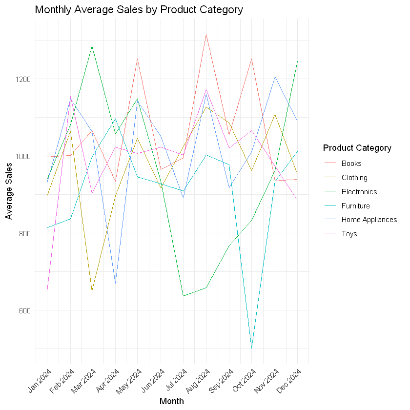

```r
ggplot(monthly_avg_sales_per_category, aes(x = Month, y = Average_Sales, color = Product_Category)) +
  geom_line() +  # Line plot for continuous data
  labs(title = "Monthly Average Sales by Product Category",
       x = "Month",
       y = "Average Sales",
       color = "Product Category") +
  theme_minimal() +
  scale_x_date(date_labels = "%b %Y", date_breaks = "1 month") +
  theme(axis.text.x = element_text(angle = 45, hjust = 1))
```

**Q2b)(5 points) Calculate the rolling means of average monthly sales (calculated in 2a) using a 3 month window. Use the center alignment to calculate the rolling means.**

**Now again plot the monthly average sales of each product category along with the rolling means.**

**i) What difference do you observe? How are the rolling means beneficial as compared to simple averages?**

```r
library(zoo)
```

```r
# Define the window size
window_size <- 3

# Calculate rolling mean
monthly_avg_sales_per_category <- monthly_avg_sales_per_category %>%
  group_by(Product_Category) %>%
  mutate(Rolling_Mean = rollapply(Average_Sales, width = window_size,
                                   FUN = mean, align = "center", fill = NA)) %>%
  ungroup()

print(monthly_avg_sales_per_category)
```

```
# A tibble: 72 x 4
   Month      Product_Category Average_Sales Rolling_Mean
   <date>     <fct>                    <dbl>        <dbl>
 1 2024-01-01 Books                     997.          NA
 2 2024-01-01 Clothing                  896.          NA
 3 2024-01-01 Electronics               939.          NA
 4 2024-01-01 Furniture                 814.          NA
 5 2024-01-01 Home Appliances           930.          NA
 6 2024-01-01 Toys                      649.          NA
 7 2024-02-01 Books                    1002.        1022.
 8 2024-02-01 Clothing                 1065.         870.
 9 2024-02-01 Electronics              1082.        1102.
10 2024-02-01 Furniture                 837.         883.
# ... with 62 more rows
```

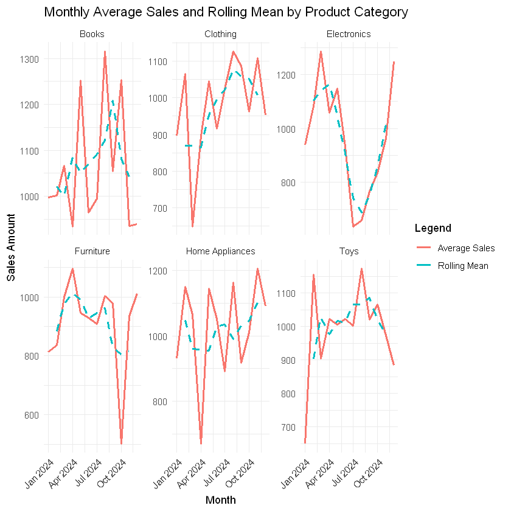

```r
# Plot using ggplot2
ggplot(monthly_avg_sales_per_category, aes(x = Month)) +
  geom_line(aes(y = Average_Sales, color = "Average Sales"), size = 1) +
  geom_line(aes(y = Rolling_Mean, color = "Rolling Mean"), size = 1, linetype = "dashed") +
  facet_wrap(~ Product_Category, scales = "free_y") +
  labs(title = "Monthly Average Sales and Rolling Mean by Product Category",
       x = "Month",
       y = "Sales Amount",
       color = "Legend") +
  theme_minimal()+
  theme(axis.text.x = element_text(angle = 45, hjust = 1))
```

**Response to Q2b**

We observe that rolling means smooth out the fluctuations in the data. It is easier to observe trends and patterns more clearly. Rolling means reduce the noise and outliers in the data.

## Question 3: Data Exploration (8 points)

**For this question, use trainData_sales**

**Q3a)(4 points) Create a boxplot of the response variable versus the following predicting variables**

**i) Store_Location**

**ii) Product_Category**

**Explain the relationship between the response and the two variables based on the boxplots.**

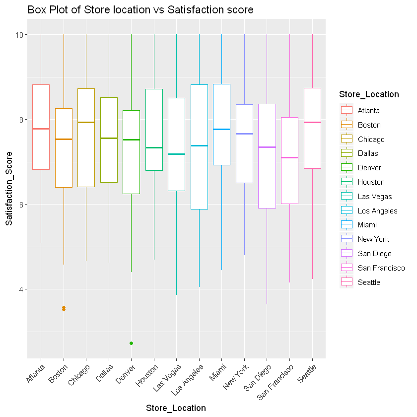

```r
#Code to create plot
library(ggplot2)
ggplot(trainData_sales, aes(x=Store_Location, y=Satisfaction_Score, color=Store_Location)) +
geom_boxplot() +
theme(axis.text.x = element_text(angle = 45, hjust = 1))+
ggtitle("Box Plot of Store location vs Satisfaction score")
```

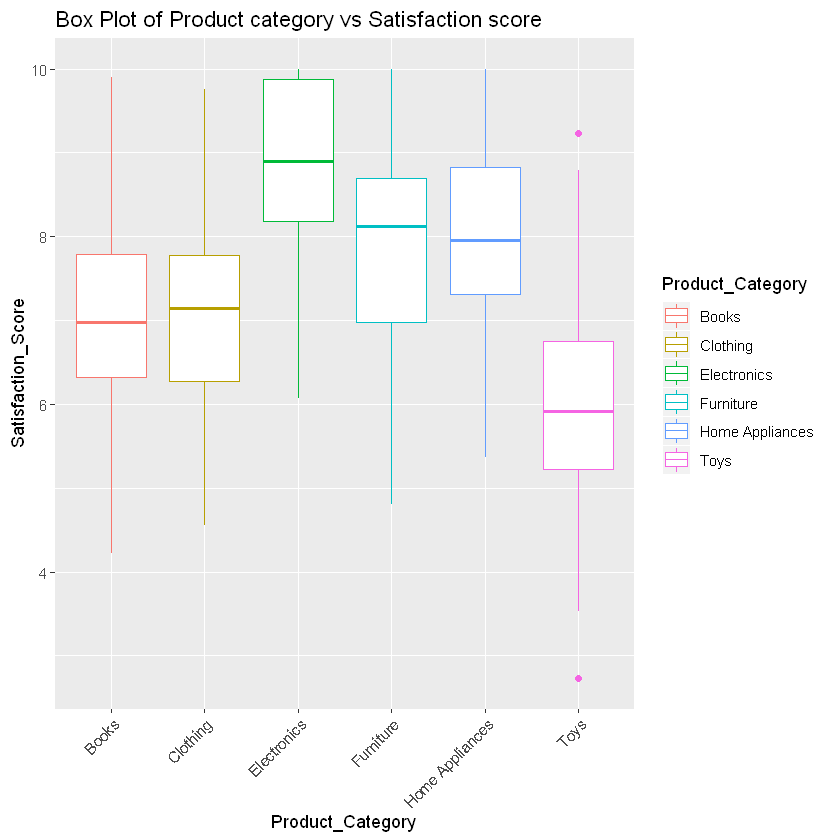

```r
ggplot(trainData_sales, aes(x=Product_Category, y=Satisfaction_Score, color=Product_Category)) +
geom_boxplot() +
theme(axis.text.x = element_text(angle = 45, hjust = 1))+
ggtitle("Box Plot of Product category vs Satisfaction score")
```

**Response to Q3**

i) The boxplot shows the highest average satisfaction score for store location in Seattle. Since the boxplots are overlapping, we cannot say that the means are statistically significantly different. Further analysis is required. **Any valid observations about the boxplots is acceptable as long as it notes that nothing statistically significant can be said from the graph alone**

ii) The boxplot shows the highest average satisfaction score for product category electronics. Since the boxplots are overlapping, we cannot say that the means are statistically significantly different. Further analysis is required. **Any valid observations about the boxplots is acceptable as long as it notes that nothing statistically significant can be said from the graph alone**

**Q3b)(4 points) Create scatterplots of the response variable against the following predictors:**

**i) Customer_Age**

**ii) Purchase_Amount**

**Describe the general trend of each plot.**

**Output the R^2 for each plot. Use the following R^2 cut-offs while explaining if it is a weak, moderate, or strong relationship.**

**R^2<=0.3 (weak)**

**0.3<R^2<0.7 (moderate)**

**R^2>=0.7 (strong)**

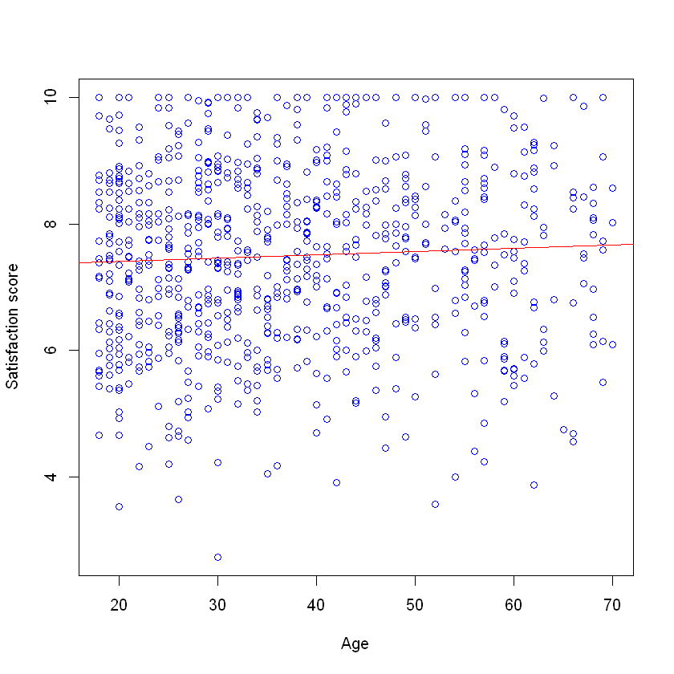

```r
# Your code here...

plot(trainData_sales$Customer_Age, trainData_sales$Satisfaction_Score , xlab="Age" , ylab="Satisfaction score", col="blue")
abline(lm(Satisfaction_Score~Customer_Age, data = trainData_sales),col="red")
```

```r
# Fit the linear model
model <- lm(Satisfaction_Score ~ Customer_Age, data = trainData_sales)
# Output the R-squared value
r_squared <- summary(model)$r.squared
print(paste("R-squared:", r_squared))
```

```
[1] "R-squared: 0.00258152264498219"
```

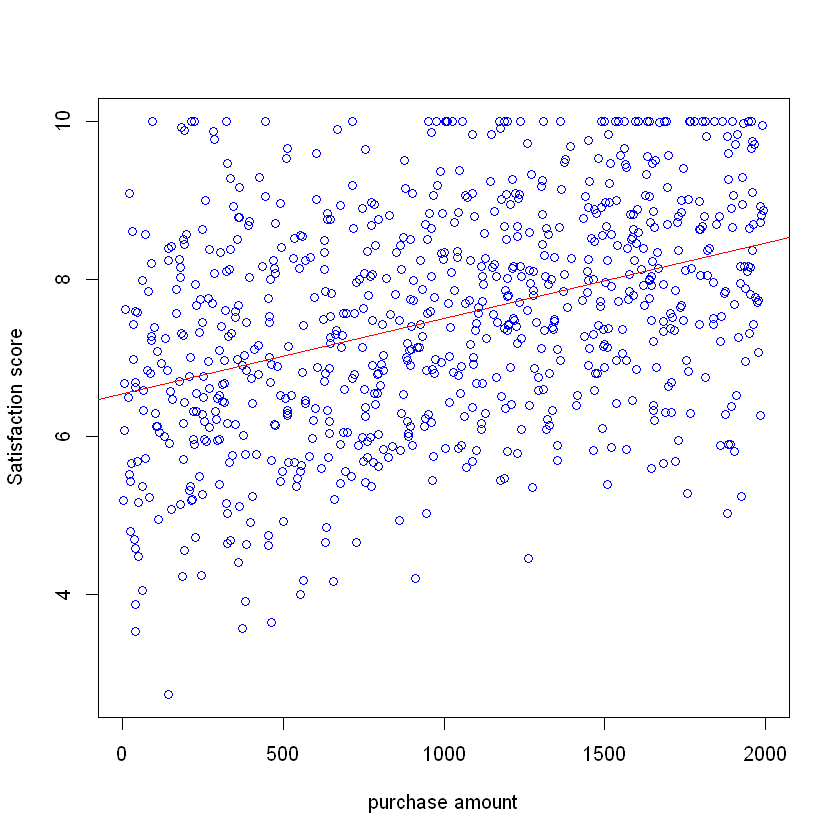

```r
plot(trainData_sales$Purchase_Amount, trainData_sales$Satisfaction_Score , xlab="purchase amount" , ylab="Satisfaction score", col="blue")
abline(lm(Satisfaction_Score~Purchase_Amount, data = trainData_sales),col="red")
```

```r
# Fit the linear model
model_amount <- lm(Satisfaction_Score ~ Purchase_Amount, data = trainData_sales)
# Output the R-squared value
r_squared_amount <- summary(model_amount)$r.squared
print(paste("R-squared:", r_squared_amount))
```

```
[1] "R-squared: 0.14677697891956"
```

**Response to Q3b** There appears to be no or very weak relationship between customer age and satisfaction score. The scatterplot shows positive relationship between purchase amount and satisfaction score. Both the plots show weak relationship according to the R^2 values.

## Question 4: Simple linear regression and ANOVA (12 points)

**For this question, use trainData_sales**

**Q4a) (5 points) Create a simple linear regression model using the predictor "Purchase_Amount". Call it model1. Display the summary.**

**i) What are the model parameters and their estimates?**

**ii) Interpret the coefficient of the predictor "Purchase_Amount" in the context of the problem.**

**iii) Find a 95% confidence interval for the coefficient of "Purchase_Amount". Is the coefficient significant at this level?**

```r
model1=lm(Satisfaction_Score~Purchase_Amount,data=trainData_sales)
summary(model1)
```

```
Call:
lm(formula = Satisfaction_Score ~ Purchase_Amount, data = trainData_sales)

Residuals:
    Min      1Q  Median      3Q     Max
-3.9529 -0.8960 -0.0057  0.9767  3.3668

Coefficients:
                 Estimate Std. Error t value Pr(>|t|)
(Intercept)     6.5431520  0.0937456   69.80   <2e-16 ***
Purchase_Amount 0.0009585  0.0000818   11.72   <2e-16 ***
---
Signif. codes:  0 '***' 0.001 '**' 0.01 '*' 0.05 '.' 0.1 ' ' 1

Residual standard error: 1.327 on 798 degrees of freedom
Multiple R-squared:  0.1468,	Adjusted R-squared:  0.1457
F-statistic: 137.3 on 1 and 798 DF,  p-value: < 2.2e-16
```

**Response to Q4a** i) The model parameters are the intercept and its estimate=6.543, ß1(coefficient of PurchaseAmount)=0.0009585 and the variance of the error terms=1.33^2=1.77

ii) The coefficient of Purchase_Amount is 0.0009585. For an increase of a dollar in the purchase amount, the satisfaction score increase by 0.0009585.

iii)

```r
confint(model1)
```

|  | 2.5 % | 97.5 % |
| --- | --- | --- |
| (Intercept) | 6.3591349416 | 6.727169038 |
| Purchase_Amount | 0.0007978727 | 0.001119022 |

Since the confidence interval does not include zero, the coefficient of purchase_amount is statistically significant.

**Q4b)(3 points) Is the coefficient of Purchase_Amount statistically significant?**

**i) State the null hypothesis**

**ii) State the alternative hypothesis**

**iii) Which test is used for testing the significance of coefficient?**

**Response to Q4b**

i) Null hypothesis: coefficient of Purchase_Amount ( ß1)=0

ii) Alternative hypothesis: coefficient of Purchase_Amount ( ß1)!=0

iii) t-test is used for testing the significance of coefficient.

**Q4c)( 4 points) Perform an ANOVA F-test on the means of Product_Category.**

**i) State the null and alternative hypotheses.**

**ii) Using an α-level of 0.01, do we reject the null hypothesis that the means are equal? Explain your conclusion.**

**iii) Which means are plausibly similar at the confidence level of 99%?**

**iv) Compare the satisfaction score of the following pair of product categories:**

**Electronics-Clothing**

```r
model_anova=aov(Satisfaction_Score~Product_Category,data=trainData_sales)
summary(model_anova)
```

```
                  Df Sum Sq Mean Sq F value Pr(>F)
Product_Category   5  674.9  134.97   110.2 <2e-16 ***
Residuals        794  972.5    1.22
---
Signif. codes:  0 '***' 0.001 '**' 0.01 '*' 0.05 '.' 0.1 ' ' 1
```

**Response to Q4c**

i) Null hypothesis: All the means are equal , Alternative hypothesis: At least two means statistically significant from each other.

ii) The p-value of the F-test is <2e-16 which is less than alpha level of 0.01. We reject the null hypothesis that the means of all the product categories are equal and conclude that at least two means statistically significantly differ from each other.

```r
TukeyHSD(model_anova,conf.level=0.99)
```

```
  Tukey multiple comparisons of means
    99% family-wise confidence level

Fit: aov(formula = Satisfaction_Score ~ Product_Category, data = trainData_sales)

$Product_Category
                                   diff        lwr        upr     p adj
Clothing-Books               0.03700886 -0.4171450  0.4911627 0.9997875
Electronics-Books            1.79972660  1.3547529  2.2447003 0.0000000
Furniture-Books              0.89568210  0.4220455  1.3693187 0.0000000
Home Appliances-Books        0.91781089  0.4704596  1.3651622 0.0000000
Toys-Books                  -1.06748120 -1.5173015 -0.6176609 0.0000000
Electronics-Clothing         1.76271774  1.3101126  2.2153229 0.0000000
Furniture-Clothing           0.85867325  0.3778599  1.3394866 0.0000000
Home Appliances-Clothing     0.88080203  0.4258592  1.3357449 0.0000000
Toys-Clothing               -1.10449006 -1.5618610 -0.6471192 0.0000000
Furniture-Electronics       -0.90404450 -1.3761963 -0.4318927 0.0000000
Home Appliances-Electronics -0.88191572 -1.3276947 -0.4361367 0.0000000
Toys-Electronics            -2.86720780 -3.3154645 -2.4189511 0.0000000
Home Appliances-Furniture    0.02212878 -0.4522644  0.4965220 0.9999866
Toys-Furniture              -1.96316330 -2.4398855 -1.4864411 0.0000000
Toys-Home Appliances        -1.98529208 -2.4359090 -1.5346752 0.0000000
```

**Response to Q4ciii**

Based on the lower and upper bounds and p-values of each pair, it is plausible that the means of clothing and books are similar because the confidence interval includes zero and the p-value is large.

It is also plausible that the means of home appliances and furniture are similar because the confidence interval includes zero and the p-value is large.

**Response to Q4civ** The product category “Electronics” has statistically significantly higher satisfaction score than “Clothing” on average.

## Question 5: Model Diagnostics (14 points)

**Q5a)(4 points) Perform the following model diagnostics on model1 created in Q4a.**

**i) Check for linearity assumption**

**ii) Check for constant variance**

**iii) Check for normality**

**Note: Both a histogram and a normal QQ plot with a pointwise confidence envelope must be plotted (tip: qqPlot() from the car package can generate a pointwise confidence envelope.**

**Explain your conclusion**

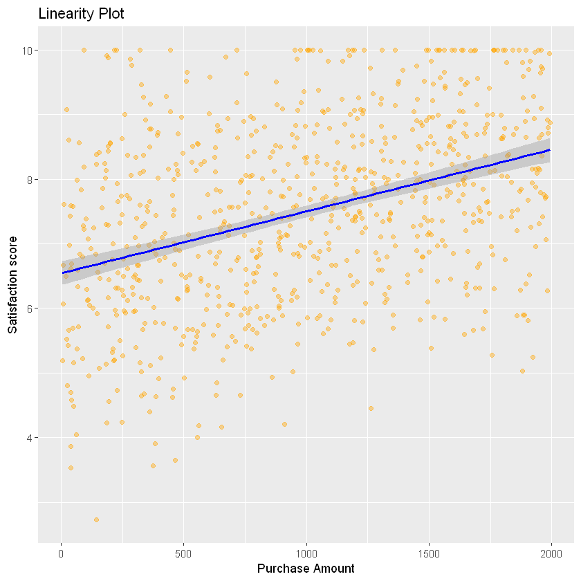

```r
ggplot(data=trainData_sales,aes(x=trainData_sales$Purchase_Amount,y=trainData_sales$Satisfaction_Score))+
  geom_point(alpha=I(0.4),color='orange')+
  xlab('Purchase Amount')+
  ylab('Satisfaction score')+
  ggtitle('Linearity Plot')+
  geom_smooth(method = "lm", color = "blue")
```

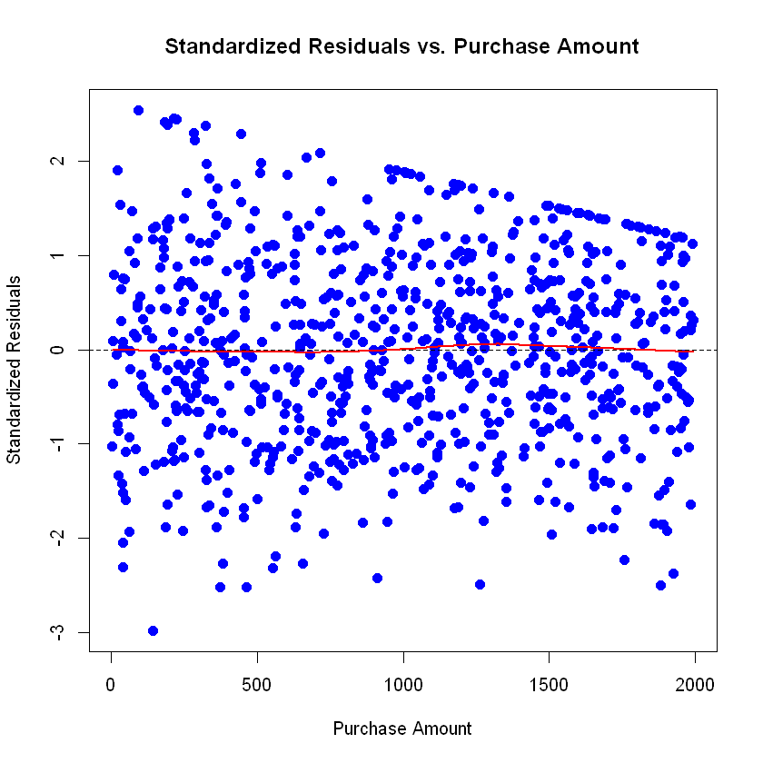

```r
model1_sresids <- rstandard(model1)

# Plotting standardized residuals vs. purchase amount
plot(trainData_sales$Purchase_Amount, model1_sresids,
     xlab = "Purchase Amount",
     ylab = "Standardized Residuals",
     main = "Standardized Residuals vs. Purchase Amount",
     pch = 19, col = "blue",
     cex = 1.2) # Increase point size

# Add a dashed line at y = 0
abline(h = 0, lty = 2, col = "black")

lines(lowess(trainData_sales$Purchase_Amount, model1_sresids), col = "red", lwd = 2)
```

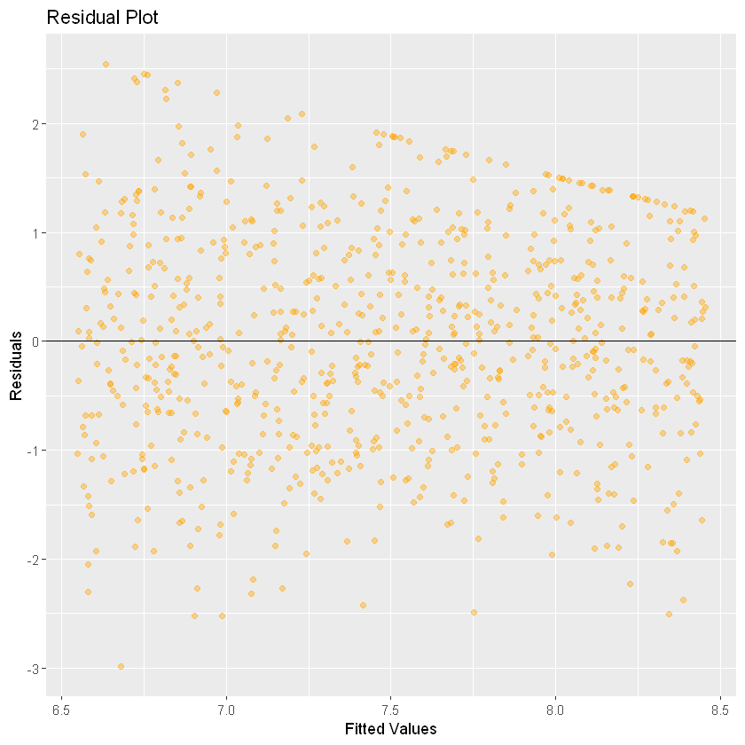

```r
# Your code here
ggplot(data=trainData_sales, aes(x=model1$fitted.values, y=(model1_sresids))) +
geom_point(alpha=I(0.4),color='orange') +
xlab('Fitted Values') +
ylab('Residuals') +
ggtitle('Residual Plot') +
geom_hline(yintercept=0)
```

```r
library(car)
```

1. 180

2. 594

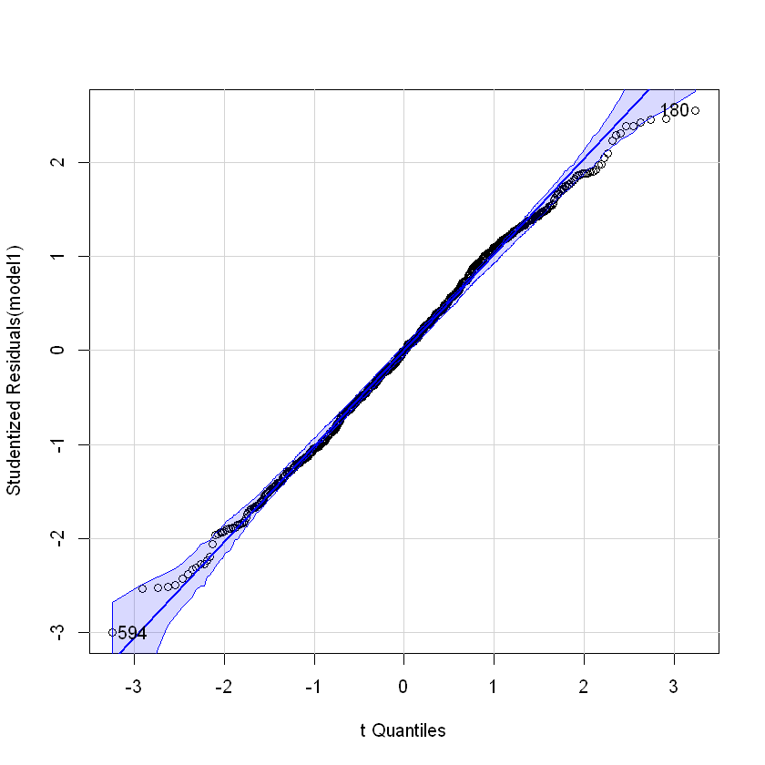

```r
qqPlot(model1,data=trainData_sales,envelope=TRUE)
```

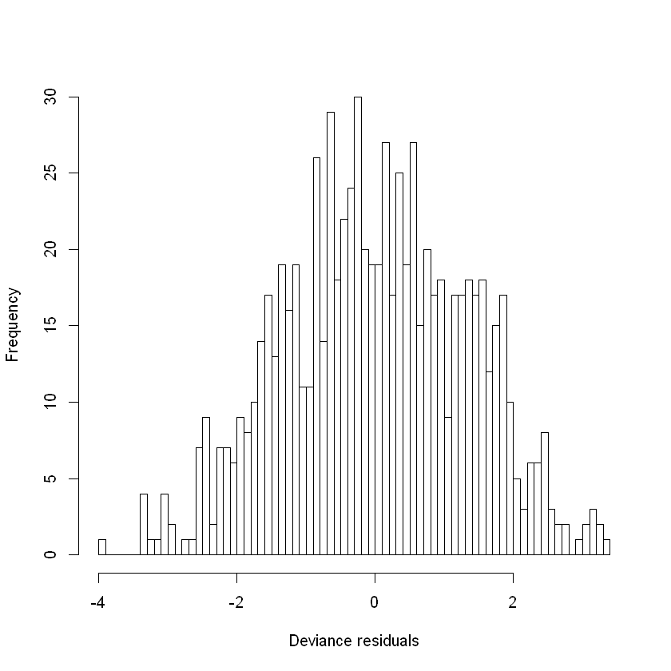

```r
#histogram
res = resid(model1,type="deviance")
hist(res,100,xlab="Deviance residuals", main="")
```

**Response to Q5a**

When points fall outside of the pointwise confidence envelope in a Q-Q plot, it suggests that the data may not follow a normal distribution. Since such a deviation was observed, we might consider transforming the data (e.g., using a log transformation) or using non-parametric methods that do not assume normality. In the residuals vs fitted values plot, the variance is slightly decreasing which means the constant variance assumption does not hold. Based on the plot between the response variable and the predictor and the plot of residuals vs predictor, we can safely say that the relationship between the two is linear (though not strong).

**Q5b)(1 point) Based on your conclusion in Q5a, would you propose any transformation of the predictor or response variable? Explain with reasoning.**

**Response to Q5b** Since normality assumption has been violated, we might consider transforming the data (e.g., using a log transformation) or using non-parametric methods that do not assume normality. **Any response so long as it is consistent with the findings in 5a should be accepted.**

**Q5c)(2 points) Suppose you have fit a simple linear regression model using Sales as the response variable and Advertising as the predictor. You are** **interested in understanding the difference between confidence intervals and prediction intervals.**

**i) Briefly explain the difference between a confidence interval for the mean response and a prediction interval for a new observation at a given** **value of the predictor.**

**ii) Why is the prediction interval wider than the confidence interval?**

**iii) Suppose that for an Advertising value of 100, the fitted model returns the following:**

**95% Confidence Interval: (10.2, 11.4)**

**95% Prediction Interval: (7.5, 14.1)**

**Interpret each interval in the context of the problem.**

**iv) If the residual plot shows evidence of non-constant variance, how might that impact the reliability of the prediction interval? How might a log** **transformation of the response variable help address this issue?**

**Response to Q5c**

i) A confidence interval provides a range of plausible values for the mean response at a given value of the predictor. A prediction interval provides a range for a new individual response at that same predictor value, accounting for both uncertainty in the mean estimate and the variability of individual outcomes.

ii) The prediction interval is wider because it incorporates both the uncertainty in estimating the mean response and the additional variation due to individual error. In contrast, the confidence interval only reflects uncertainty in the mean.

iii) The 95% confidence interval of (10.2, 11.4) means we are 95% confident that the average sales for all observations with an advertising budget of 100 fall within this range. The 95% prediction interval of (7.5, 14.1) means we are 95% confident that a new observation with an advertising budget of 100 will have a sales value within that range.

iv) If the residual plot suggests non-constant variance (heteroscedasticity), then the model’s assumption of equal variance across levels of the predictor is violated. This can make prediction intervals unreliable because the estimated standard error varies with the predictor value. Applying a log transformation to the response variable can stabilize the variance, improving the accuracy and interpretability of interval estimates.

**Q5d)(2 points) Create a linear regression model, named model2, that uses the log transformed Satisfaction_Score as the response, and the log transformed Purchase_Amount as the predictor. Display the summary.**

```r
model2=lm(log(Satisfaction_Score)~log(Purchase_Amount),data=trainData_sales)
summary(model2)
```

```
Call:
lm(formula = log(Satisfaction_Score) ~ log(Purchase_Amount),
    data = trainData_sales)

Residuals:
     Min       1Q   Median       3Q      Max
-0.86480 -0.12028  0.01694  0.13832  0.47907

Coefficients:
                     Estimate Std. Error t value Pr(>|t|)
(Intercept)          1.485931   0.046705   31.82   <2e-16 ***
log(Purchase_Amount) 0.077005   0.007001   11.00   <2e-16 ***
---
Signif. codes:  0 '***' 0.001 '**' 0.01 '*' 0.05 '.' 0.1 ' ' 1

Residual standard error: 0.1906 on 798 degrees of freedom
Multiple R-squared:  0.1316,	Adjusted R-squared:  0.1306
F-statistic:   121 on 1 and 798 DF,  p-value: < 2.2e-16
```

**Q5e)(2 points) Compare the R-squared values of model1 and model2. Did the transformation improve the explanatory power of the model?**

**Response to Q5e**

model1 $\rightarrow R^2 : 0.1468$  
model2 $\rightarrow R^2 : 0.1316$

The transformation has reduced the explanatory power of the model.

**Q5f) (3 points) Perform the same model diagnostics on model2 as you did on model1 in Q5a. Assess and interpret all model assumptions. Based on your interpretation of the model assumptions, is model2 a better fit than model1? A model is considered a good fit only if all the assumptions hold.**

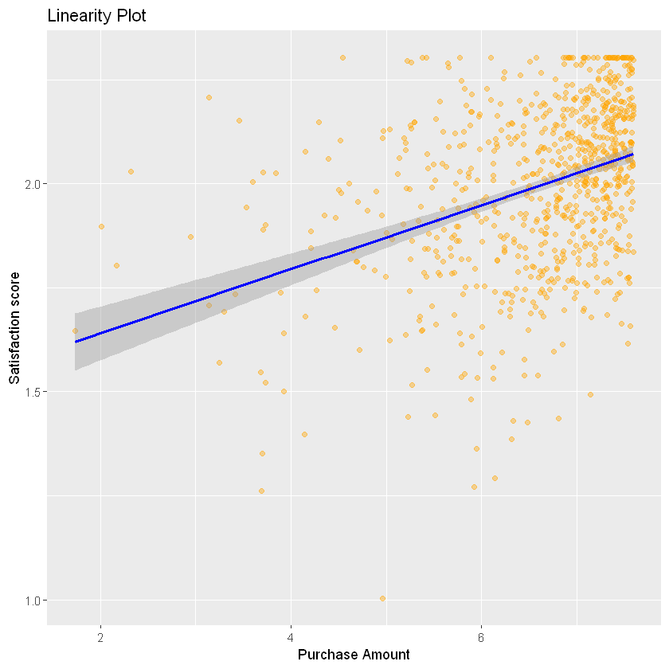

```r
ggplot(data=trainData_sales,aes(x=log(trainData_sales$Purchase_Amount),y=log(trainData_sales$Satisfaction_Score)))+
  geom_point(alpha=I(0.4),color='orange')+
  xlab('Purchase Amount')+
  ylab('Satisfaction score')+
  ggtitle('Linearity Plot')+
  geom_smooth(method = "lm", color = "blue")
```

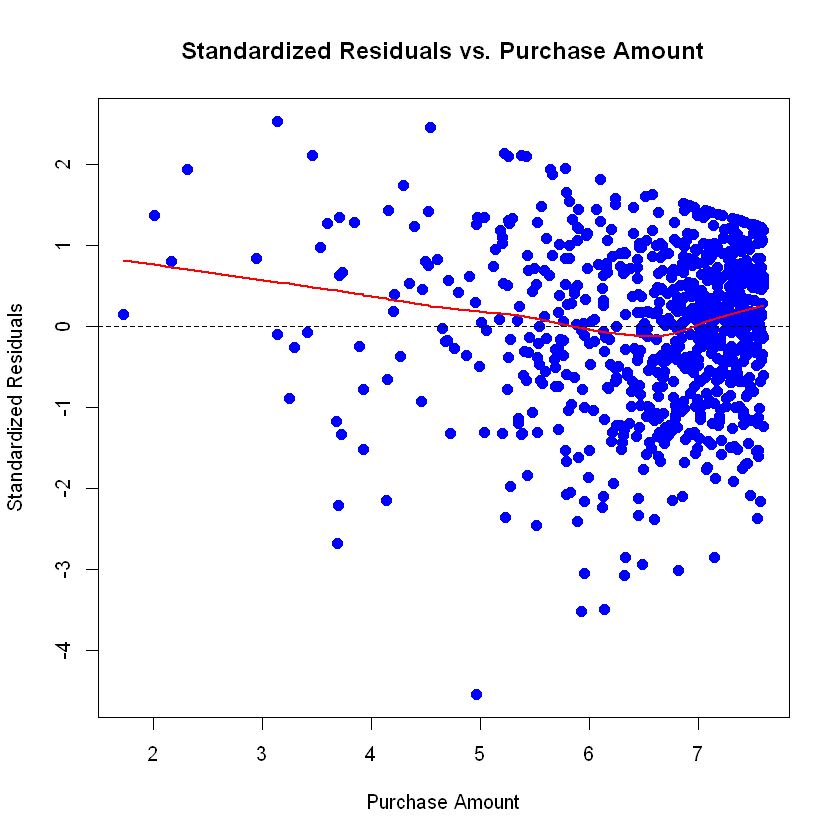

```r
model2_sresids <- rstandard(model2)

# Plotting standardized residuals vs. purchase amount
plot(log(trainData_sales$Purchase_Amount), model2_sresids,
     xlab = "Purchase Amount",
     ylab = "Standardized Residuals",
     main = "Standardized Residuals vs. Purchase Amount",
     pch = 19, col = "blue",
     cex = 1.2) # Increase point size

# Add a dashed line at y = 0
abline(h = 0, lty = 2, col = "black")

lines(lowess(log(trainData_sales$Purchase_Amount), model2_sresids), col = "red", lwd = 2)
```

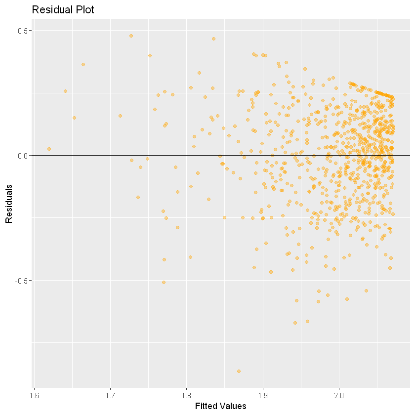

```r
ggplot(data=trainData_sales, aes(x=model2$fitted.values, y=model2$residuals)) +
geom_point(alpha=I(0.4),color='orange') +
xlab('Fitted Values') +
ylab('Residuals') +
ggtitle('Residual Plot') +
geom_hline(yintercept=0)
```

1. 353

2. 594

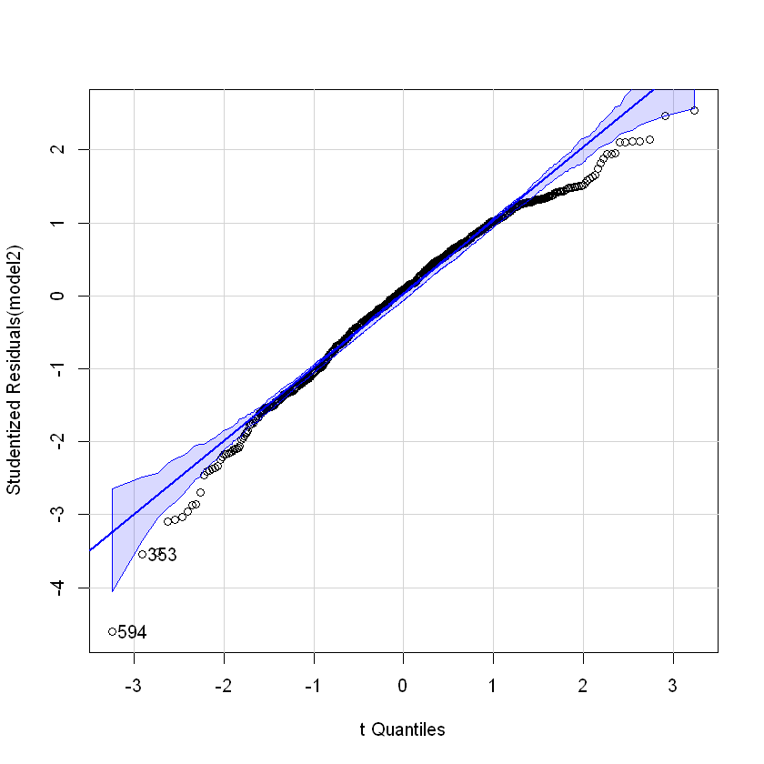

```r
qqPlot(model2,data=trainData_sales,envelope=TRUE)
```

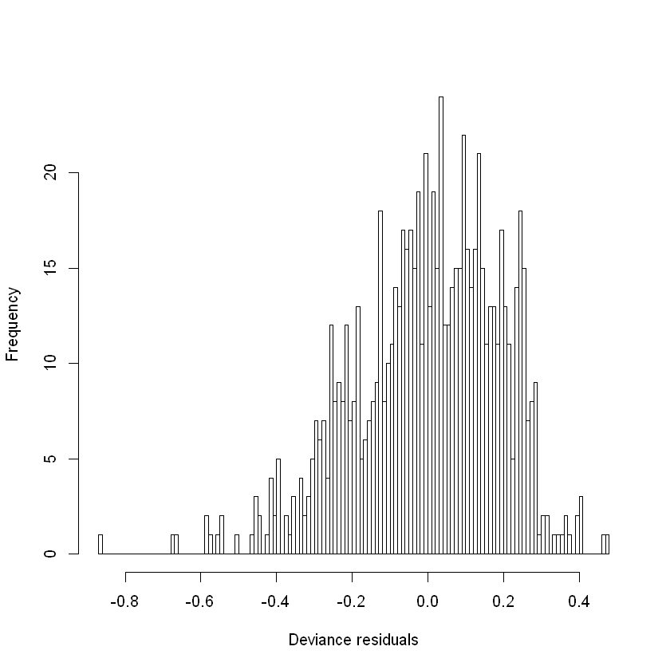

```r
#histogram
res = resid(model2,type="deviance")
hist(res,100,xlab="Deviance residuals", main="")
```

**Response to Q5f**

According to the plots, linearity, constant variance are violated. In the residuals vs predictor plot, there seems to be a non-linear pattern (curvature in the red line) in the residuals. In the residuals vs fitted values plot, the variance of the residuals is not constant as the fitted values increase which means the constant variance assumption does not hold. Since we have points that fall outside the confidence envelope in the QQplot, normality assumption does not hold. The histogram also appears to be skewed.

Model 1 appears to be a better fit than Model 2.

## Question 6: Prediction (5 points)

**For this question, use testData_sales**

**Q6a)(3 points) Using testData_sales, predict the satisfaction score using model1.**

i) **Show the first 10 predictions along with their true values.**

ii) **Calculate the mean squared prediction error.**

iii) **Calculate average and standard deviation of the predictions of the satisfaction score using model1.**

```r
predict_model1=predict(model1,testData_sales,type='response')
predictions = data.frame(Satisfaction_Score=testData_sales$Satisfaction_Score, predict_model1)
head(predictions,10)
```

|  | Satisfaction_Score | predict_model1 |
| --- | --- | --- |
| 714 | 9.401932 | 8.031362 |
| 503 | 5.557678 | 6.550302 |
| 358 | 8.634280 | 7.832033 |
| 624 | 8.394701 | 7.974056 |
| 985 | 9.168275 | 7.275348 |
| 718 | 4.708268 | 6.963268 |
| 919 | 9.076011 | 8.280098 |
| 470 | 8.757487 | 8.411673 |
| 966 | 7.671931 | 7.794002 |
| 516 | 10.000000 | 7.300258 |

```r
#Prediction error
MSPE=mean((predict_model1 - testData_sales$Satisfaction_Score)^2)
print("Mean squared prediction error")
print(MSPE)
print("Mean prediction")
print(mean(predict_model1))
print("standard deviation of the predictions of the satisfaction score")
print(sd(predict_model1))
```

```
[1] "Mean squared prediction error"
[1] 1.785631
[1] "Mean prediction"
[1] 7.496399
[1] "standard deviation of the predictions of the satisfaction score"
[1] 0.5212317
```

**Q6b)(2 points) Using the first row of testData_sales, predict the satisfaction score using model1. What is the 99% prediction interval (PI)? Provide an interpretation of your results.**

```r
testpoint=testData_sales[1,]
predict(model1,testpoint,interval="prediction",level=0.99)
```

|  | fit | lwr | upr |
| --- | --- | --- | --- |
| 714 | 8.031362 | 4.600441 | 11.46228 |

**Response to Q6b**

The predicted value for the satisfaction score is 8.03 with lower bound 4.60 and upper bound 11.46. We can be 99% confident that the satisfaction score with the above characteristics is between 4.60 and 11.46.

## **Question 7: Research Question (2 points)**

**(2 points) Research and explain the arguments that go into the predict function in detail. Please include object, newdata, interval, type, se.fit, and level.**

**Response to Q7**

The predict function in R is used to make predictions based on a model object. Here are the key arguments that go into the predict function:

*object*: This is the model object you have created, such as a linear regression model (lm), generalized linear model (glm), or any other model object. It contains the fitted model that will be used for making predictions.  
*newdata*: This is a data frame containing the new data for which you want to make predictions. The structure of newdata should match the structure of the data used to fit the model.  
*interval*: This argument specifies the type of interval calculation. Common options include “none” (default), “confidence”, and “prediction”. These intervals provide additional information about the uncertainty of the predictions.  
*type*: This argument specifies the type of prediction to make. For example, in the context of a generalized linear model, you might use “response” to get predictions on the scale of the response variable or “link” to get predictions on the scale of the linear predictors.  
*se.fit*: This logical argument indicates whether standard errors of the predictions should be returned. If set to TRUE, the function will return standard errors along with the predictions.  
*level*: This argument specifies the confidence level for the interval. The default is usually 0.95, corresponding to a 95% confidence interval.

## Question 8: Changing the Baseline (3 points)

**(3 points) In the pre-processing of the data we did: Sales_dataset\$Product_Category = as.factor(Sales_dataset\$Product_Category) , explain ways using both code and descriptions that you can tell what the baseline is and how you can change the baseline for Product_Category.**

**Response to Q8** To determine and change the baseline (reference level) of a factor variable in R, you can use the levels and relevel functions. Here’s how you can do it: Determine the Baseline First, you can check the levels of the factor to see what the current baseline is:

```r
# Convert the variable to a factor
Sales_dataset$Product_Category <- as.factor(Sales_dataset$Product_Category)

# Check the levels of the factor
levels(Sales_dataset$Product_Category)
```

1. 'Books'

2. 'Clothing'

3. 'Electronics'

4. 'Furniture'

5. 'Home Appliances'

6. 'Toys'

The first level in the output is the current baseline. Change the Baseline To change the baseline, you can use the relevel function. For example, if you want to set “Clothing” as the baseline:

```r
# Change the baseline to "Clothing"
Sales_dataset$Product_Category <- relevel(Sales_dataset$Product_Category, ref = "Clothing")

# Verify the change
levels(Sales_dataset$Product_Category)
```

1. 'Clothing'

2. 'Books'

3. 'Electronics'

4. 'Furniture'

5. 'Home Appliances'

6. 'Toys'

The specified category (“Clothing”) will become the new baseline.

**The End**